# visualization

**Data Visualization in Python**

Data is by far the biggest asset for any business. If left idle, the information lost could cost us a dime. In this documentation, I will explaining different ways of visualizaing data within python.

Few of most common uses are: Histograms, Barplots and Scatterplots.

Knowledge requirements: None but Basic python preferred.

Packages used: Matplotlib and Seaborn

Datasets: student performance data and CoV data both are readily accessible.

Let's use student performance data to learn the basics and then dive into Covid tracking data to do a deeper analysis.

```python
import pandas as pd
import seaborn as sns
sns.set()
```

```python
#Reading the datasets

#We use pandas built in function .read_csv() to read the link that directs to a dataset
students_df = pd.read_csv("https://tf-assets-prod.s3.amazonaws.com/tf-curric/data-science/studentsperformance.csv")
cov_df = pd.read_csv("https://covidtracking.com/api/states/daily.csv")
```

**Understanding distribution with histograms**

The histogram can help you quickly analyze a variable's distribution. In this, you'll focus on the math, reading, and writing scores; you'll investigate how they are distributed in student performance data.

```python
#select desired columns and use .describe() that returns the stats such as count mean and std deviation.
students_df[['math score', 'writing score', 'reading score']].describe()
```

|  | math score | writing score | reading score |
| --- | --- | --- | --- |
| count | 1000.00000 | 1000.000000 | 1000.000000 |
| mean | 66.08900 | 68.054000 | 69.169000 |
| std | 15.16308 | 15.195657 | 14.600192 |
| min | 0.00000 | 10.000000 | 17.000000 |
| 25% | 57.00000 | 57.750000 | 59.000000 |
| 50% | 66.00000 | 69.000000 | 70.000000 |
| 75% | 77.00000 | 79.000000 | 79.000000 |
| max | 100.00000 | 100.000000 | 100.000000 |

You can see that math has a mean of 66. Let's make a basic histogram for "math score" using the histplot function:

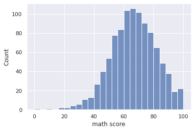

```python
#sns.histplot is a builtin function that returns the histogram of a selected column - in this case 'math score'

ax = sns.histplot(students_df['math score'])
```

What do we infer from the above plot?

The distribution at scale - we can see the spread of scores (x-axis) vs the count of the students (y-axis).

You can also choose the number of bins (bars) as per your wish that best fits the data.

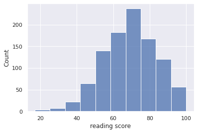

```python
#notice the x bar is compressed
x = sns.histplot(students_df['reading score'], bins=10)
```

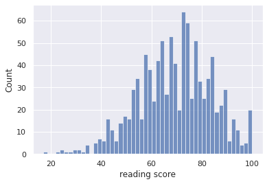

```python
#Using 50 bins
ax = sns.histplot(students_df['reading score'], bins = 50)
```

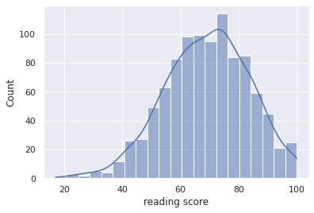

```python
ax = sns.histplot(students_df['reading score'], kde = True)
```

KDE Plot described as Kernel Density Estimate is used for visualizing the Probability Density of a continuous variable. It depicts the probability density at different values in a continuous variable.

**Bringing in Probability to visualization**

Note that the default y-axis aggregation is the raw count of observations per bin. Alternative aggregations that normalize the counts are frequently preferable; the stat parameter allows you to specify other aggregations. Below, create a final histogram on writing score, showing the percentage of observations in each bin on the y-axis:

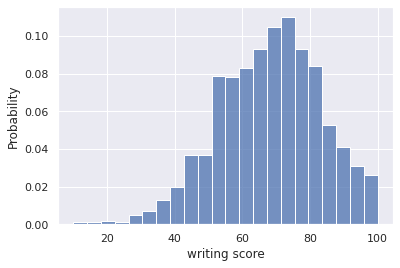

```python
ax = sns.histplot(students_df['writing score'], stat='probability')
```

**Comparing the distribution of two variables**

Next, visualize the relationship between two variables. Here, what you want is a scatter plot; for that, use the `scatterplot()` function. Now, compare math and reading scores:

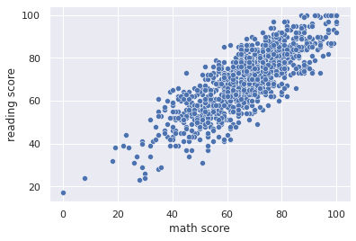

```python
sns.scatterplot(x="math score", y="reading score", data=students_df);
```

In a scatter plot, one variable is plotted on the x-axis and the other on the y-axis. It may be immediately obvious that as the math score increases, the reading score also increases. One explanation here might be that students who are good at math are also better at reading, or vice versa.

Below you will add hue to differentiate based on gender

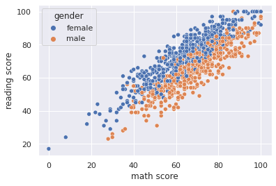

```python
sns.scatterplot(x="math score", y="reading score", hue="gender", data=students_df);
```

It looks like females are scoring higher in reading than the males. You will further explore this in another type of plot shortly.

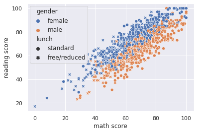

```python
sns.scatterplot(x="math score", y="reading score", hue="gender", style="lunch",  data=students_df )
```

Use size field to differentiate based on size

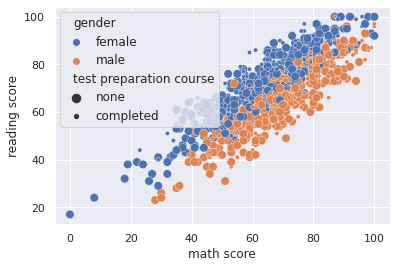

```python
sns.scatterplot(x="math score", y="reading score", hue="gender", size="test preparation course",  data=students_df);
```

**Pairplot**

To plot multiple distributions in the dataset, use the pairplot() function. It will compare all variables against each other in a matrix of plots.

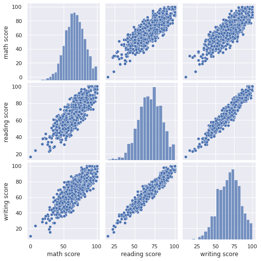

```python
sns.pairplot(students_df);
```

**Box plots**

Box plots visually illustrate the distribution of values in a category. In a box plot, the median and upper and lower quartiles are clearly shown, as well as the maximum and minimum. Two or more samples may be compared using the box plot.

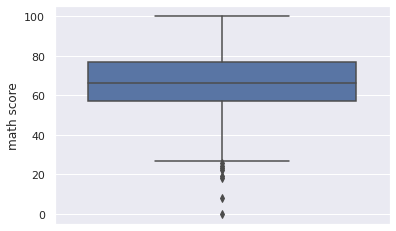

```python
sns.boxplot(y="math score", data=students_df);
```

Lower end of the box at score 60 denotes lower quartile which means 75% values above that line

The middle line in the box is the median - 50% above the line

The top line is the maximum and any dots (if any) are outliers

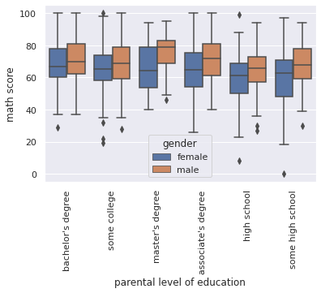

```python
#Math score gender wise
ax = sns.boxplot(y="math score", hue="gender", x = "parental level of education", data=students_df)
ax.set_xticklabels(ax.get_xticklabels(), rotation=90);
```

That marks the end of basic visualizations - Now I cannot cover visualizations in depth, there is just a lot to it. But the above information is more than enough to understand and infer knowledge from the datasets that you have.

**Intermediate Visualizations**

```python
#Data selection to grouping statewise for current positive cases
df = cov_df.loc[cov_df['state'].isin(['NY','CA', 'FL', 'TX', 'MA', 'NJ', 'IL', 'PA', 'MI', 'WA'])]
## Reset Index
df = df.reset_index(drop=True)

df1 = df.copy()
df1.date = pd.to_datetime(df['date'], format='%Y%m%d')
df1.date = df1.date.max()
count_df = df1.groupby(by=['date','state'])['positive'].max().reset_index()
count_df.sort_values('positive', ascending=False, inplace=True)
count_df = pd.DataFrame(count_df)
count_df
```

|  | date | state | positive |
| --- | --- | --- | --- |
| 0 | 2021-03-07 | CA | 3501394.0 |
| 8 | 2021-03-07 | TX | 2686818.0 |
| 1 | 2021-03-07 | FL | 1909209.0 |
| 6 | 2021-03-07 | NY | 1681169.0 |
| 2 | 2021-03-07 | IL | 1198335.0 |
| 7 | 2021-03-07 | PA | 948643.0 |
| 5 | 2021-03-07 | NJ | 812609.0 |
| 4 | 2021-03-07 | MI | 656072.0 |
| 3 | 2021-03-07 | MA | 591356.0 |
| 9 | 2021-03-07 | WA | 344532.0 |

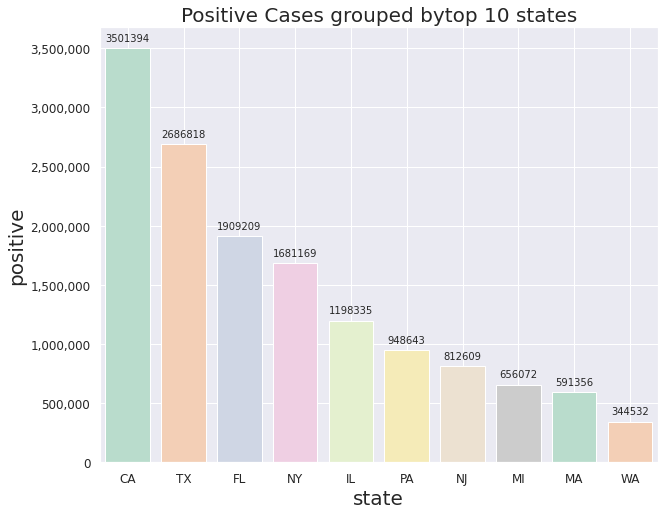

```python
#Barplot for Positive Cases
from matplotlib.ticker import StrMethodFormatter
import matplotlib
import matplotlib.pyplot as plt
import matplotlib as mpl

f, ax = plt.subplots(figsize=(10, 8))
splot = sns.barplot(x=count_df.state, y=count_df.positive,
            label="Positive counts by state",  ax=ax,
           palette="Pastel2",
           )
for p in splot.patches:
    splot.annotate(format(p.get_height(), '.0f'),
                   (p.get_x() + p.get_width() / 2.,
                    p.get_height()),
                   ha = 'center', va = 'center', xytext = (0, 10), textcoords = 'offset points')
ax.grid(axis='x')
ax.set_title("Positive Cases grouped bytop 10 states", loc='center', fontsize=20)
ax.yaxis.set_major_formatter(StrMethodFormatter('{x:,.0f}'))

ax.set_xlabel(ax.get_xlabel(), fontsize=20)
ax.set_ylabel(ax.get_ylabel(), fontsize=20)
ax.xaxis.set_tick_params(labelsize=12)
ax.yaxis.set_tick_params(labelsize=12)

plt.show()
```

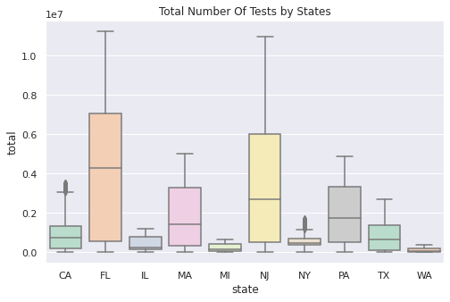

```python
#Box-plot for average of total tests
plt.figure(figsize=(8,5))
sns.boxplot(x = 'state', y = 'total', data = df, palette='Pastel2')
plt.title("Total Number Of Tests by States")
plt.show()
```

[figure not shown]

```python
#barplot for statewise recovery
plt.figure(figsize=(20,10))

sns.barplot(x=cov_df['state'].value_counts().nlargest(15).index,
            y=cov_df['recovered'].value_counts().nlargest(15), palette="Pastel2")

plt.xticks(rotation=30)
plt.title('Top 15 states with highest recovery')
plt.xlabel('state')
plt.ylabel('Number recovered cases')
plt.show()
```

**References**

*Python Software Foundation. Python Language Reference, version 3.9.7. Available at http://www.python.org*

*Thinkful Data Science Flex Material (2020)*

*The Pandas development team (2020)*

*Michael Waskom and the seaborn development team (2020)*

*J. D. Hunter, "Matplotlib: A 2D Graphics Environment", Computing in Science & Engineering, vol. 9, no. 3, pp. 90-95, (2007).*

By - Sajith G

09/14/2021

Machine Learning Engineer, Edcast